# Milestone Report, Data Science Capstone

Patrick Applegate, applegatepj@gmail.com

4 September 2016

# Introduction

Text mining is the process of extracting actionable information from textual data. In the capstone course of the Johns Hopkins Data Science Specialization offered through Coursera, students work to develop a Shiny app that can predict the next word that a user might want to enter. This report provides a preliminary check on progress toward that eventual goal.

# Methods

For this preliminary project, I used data from three corpora of text provided by engineers at SwiftKey. SwiftKey is a company that provides software for predictive text modeling. These corpora came from Twitter, blogs, and news articles.

Next, I used R to carry out the following steps:

1. determine how many lines each file contains and the length of the longest line in each file
2. subset each data set for easier processing; the subsets contain 1% as many lines as the original data sets
3. using the `tm` package,
- make a corpus,
- remove uninformative words and punctuation marks,
- create a term document matrix, and then
- determine the frequencies of different terms
4. make a barplot showing the number of occurrences of the top ten terms

To carry out steps 3 and 4, I followed examples in the DataCamp course Text Mining: Bag of Words (https://www.datacamp.com/courses/intro-to-text-mining-bag-of-words) developed by Ted Kwartler, Nick Carchedi, and Tom Jeon.

# Results

I found that

- the Twitter data set contains 2360148 lines and has a maximum line length of 140 characters,
- the blogs data set contains 899288 lines and has a maximum line length of 40833 characters, and
- the news data set contains 1010242 lines and has a maximum line length of 11384 characters.

The following plots show the top ten terms in each corpus.

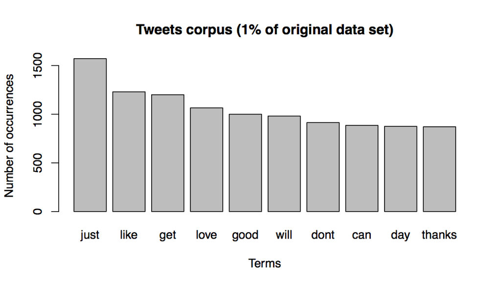

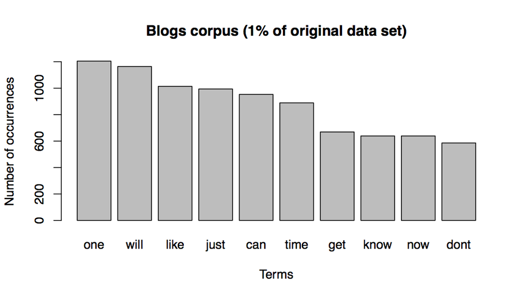

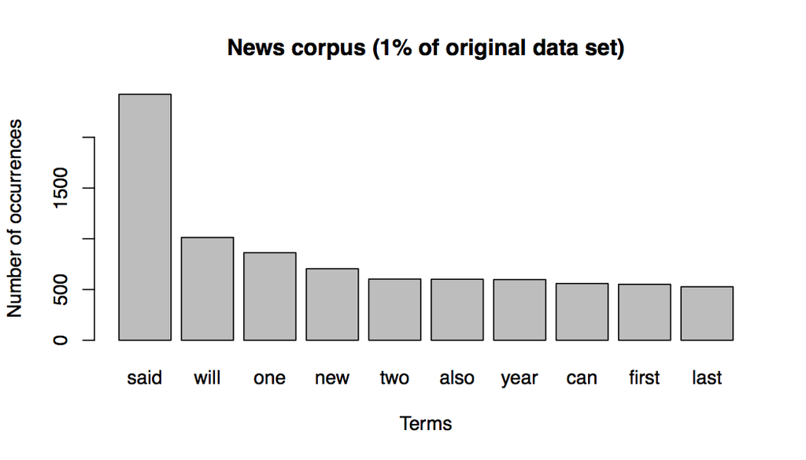

# Discussion

One insight that comes out of the plots above is that “said” is the most common non-trivial term in the news corpus; it occurs more than twice as many times as the next most common term. In contrast, this term does not occur in the list of top ten terms for either of the other two corpora. Also, the number of occurrences for the top ten terms in the Twitter and blogs corpora are much more even than in the news corpus.

As noted above, the eventual goal of this project is to develop an app that performs predictive text modeling. To do this, I will analyze the corpora provided to see which words typically follow other words. I would also like to incorporate dictionary information on parts of speech (that is, verbs, nouns, articles, etc.), so that the final app will return sensible responses when provided with words that are not in any of the corpora.